# Report 11.5

### 2.4. Hyperparameter tuning for the optimal k

```r
# we set up training control for 10-fold cross-validation
train_control_cv <- trainControl(
  method = "cv",
  number = 10
)

# We define the range of k values we want to test
k_tuning_grid <- data.frame(k = 1:30)
```

```r
set.seed(60249)

model_davos_tuned <- train(
  gpp_recipe_davos,
  data = davos_train,
  method = "knn",
  trControl = train_control_cv,
  tuneGrid = k_tuning_grid,
  metric = "MAE"

)

print("Davos KNN model tuning summary:")
```

```
## [1] "Davos KNN model tuning summary:"
```

```r
print(model_davos_tuned)
```

```
## k-Nearest Neighbors
##
## 2990 samples
##    8 predictor
##
## Recipe steps: YeoJohnson, center, scale
## Resampling: Cross-Validated (10 fold)
## Summary of sample sizes: 2692, 2691, 2691, 2690, 2690, 2692, ...
## Resampling results across tuning parameters:
##
##   k   RMSE      Rsquared   MAE
##    1  1.966411  0.5499379  1.478158
##    2  1.700980  0.6338710  1.276143
##    3  1.592637  0.6701229  1.203645
##    4  1.522966  0.6944465  1.153326
```

[output cut: 29 more lines]

```r
print(paste("Optimal k for Davos-only model (based on MAE):", model_davos_tuned$bestTune$k))
```

```
## [1] "Optimal k for Davos-only model (based on MAE): 22"
```

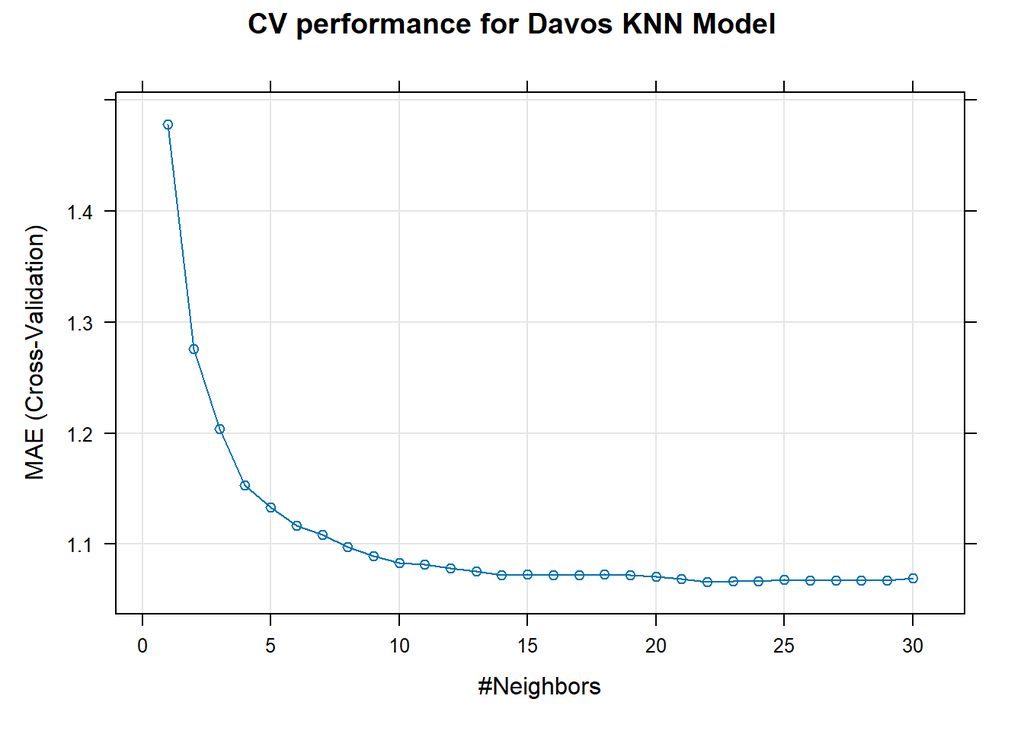

```r
plot(model_davos_tuned, main = "CV performance for Davos KNN Model")
```

```r
set.seed(60249)

model_laegeren_tuned <- train(
  gpp_recipe_laegeren,
  data = laegeren_train,
  method = "knn",
  trControl = train_control_cv,
  tuneGrid = k_tuning_grid,
  metric = "MAE"
)

print("Laegern KNN model tuning summary:")
```

```
## [1] "Laegern KNN model tuning summary:"
```

```r
print(model_laegeren_tuned)
```

```
## k-Nearest Neighbors
##
## 1615 samples
##    8 predictor
##
## Recipe steps: YeoJohnson, center, scale
## Resampling: Cross-Validated (10 fold)
## Summary of sample sizes: 1453, 1454, 1454, 1453, 1454, 1454, ...
## Resampling results across tuning parameters:
##
##   k   RMSE      Rsquared   MAE
##    1  3.331598  0.4419677  2.482525
##    2  2.894760  0.5305925  2.184075
##    3  2.751666  0.5601932  2.093080
##    4  2.683923  0.5753927  2.025452
```

[output cut: 29 more lines]

```r
print(paste("Optimal k for Laegern-only model (based on MAE):", model_laegeren_tuned$bestTune$k))
```

```
## [1] "Optimal k for Laegern-only model (based on MAE): 18"
```

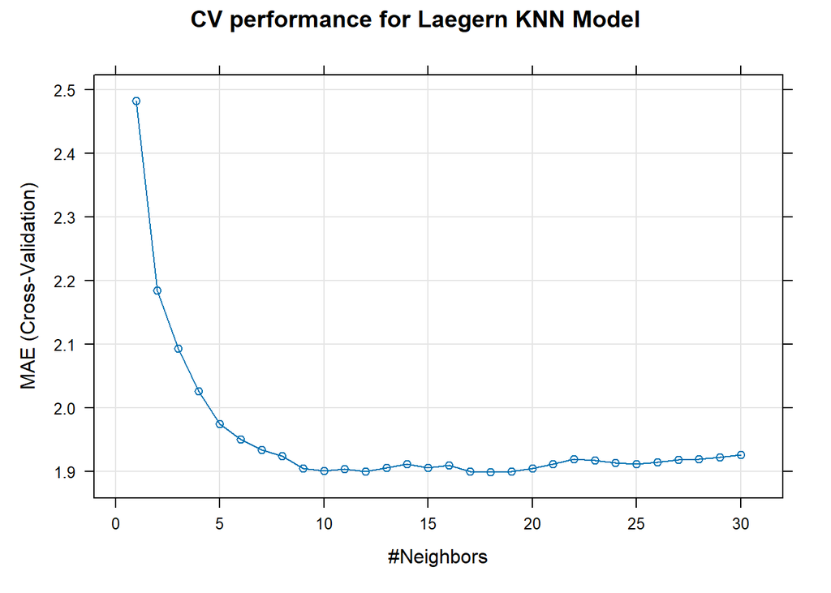

```r
plot(model_laegeren_tuned, main = "CV performance for Laegern KNN Model")
```

```r
set.seed(60249)

model_combined_tuned <- train(
  gpp_recipe_combined,
  data = combined_train,
  method = "knn",
  trControl = train_control_cv,
  tuneGrid = k_tuning_grid,
  metric = "MAE"
)

print("Combined KNN model tuning summary:")
```

```
## [1] "Combined KNN model tuning summary:"
```

```r
print(model_combined_tuned)
```

```
## k-Nearest Neighbors
##
## 4607 samples
##    8 predictor
##
## Recipe steps: YeoJohnson, center, scale
## Resampling: Cross-Validated (10 fold)
## Summary of sample sizes: 4145, 4145, 4147, 4146, 4147, 4146, ...
## Resampling results across tuning parameters:
##
##   k   RMSE      Rsquared   MAE
##    1  2.609577  0.4789089  1.931585
##    2  2.271257  0.5615561  1.694837
##    3  2.140793  0.5994640  1.592721
##    4  2.075468  0.6189944  1.542593
```

[output cut: 29 more lines]

```r
print(paste("Optimal k for Combined data model (based on MAE):", model_combined_tuned$bestTune$k))
```

```
## [1] "Optimal k for Combined data model (based on MAE): 17"
```

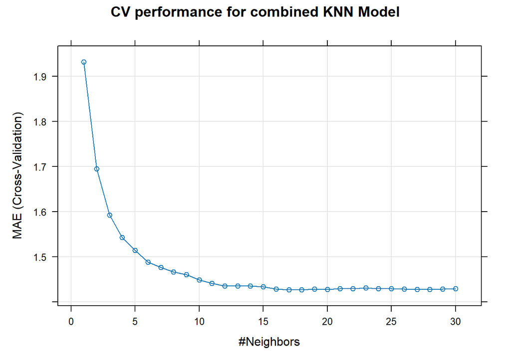

```r
plot(model_combined_tuned, main = "CV performance for combined KNN Model")
```

## 3. Model evaluation on test set

```r
# We define a function to calculate metrics and create plots
eval_model <- function(model, test_data, model_name) {

  # We make predictions on the test data
  predictions <- predict(model, newdata = test_data)

  # We create a data holding observed and predicted values
  eval_data <- data.frame(
    Observed = test_data$GPP,
    Predicted = predictions
  )

  # We calculate performance metrics using the built-in functions from the yardstick package
  rmse_calc <- yardstick::rmse_vec(eval_data$Observed, eval_data$Predicted)
  rsquared_calc <- yardstick::rsq_vec(eval_data$Observed, eval_data$Predicted)

  # Create scatter plot
  p <- ggplot(eval_data, aes(x = Observed, y = Predicted)) +
    geom_point(alpha = 0.5) +
    geom_abline(intercept = 0, slope = 1, linetype = "dashed", color = "red", linewidth = 1) + # Use linewidth
    labs(
      title = paste(model_name, ": Observed vs. Predicted GPP (test set)"),
      subtitle = paste("RMSE:", round(rmse_calc, 3), " R²:", round(rsquared_calc, 3)), # MAE removed
      x = "Observed GPP",
      y = "Predicted GPP"
    ) +
    theme_minimal() +
    coord_fixed(ratio = 1) # This ensures axes have the same scale for 1:1 comparison

  print(p) # To print the plot

  # We create a data frame of the results
  metrics_df <- data.frame(
    Evaluation_Scenario = model_name,
    R_squared = round(rsquared_calc, 3),
    RMSE = round(rmse_calc, 3)
  )

  return(metrics_df)
}
```

```r
cat("Evaluating model trained on Dacos data\n")
```

```
## Evaluating model trained on Dacos data
```

```r
davos_on_davos_metrics <- eval_model(
    model = model_davos_tuned,
    test_data = davos_test,
    model_name = "Davos-trained on Davos test"
)
```

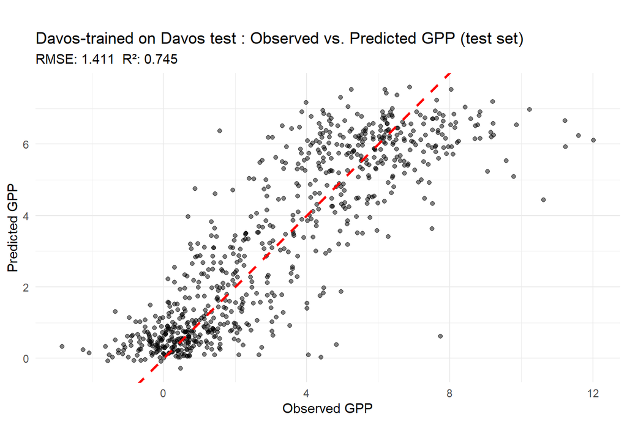

```r
davos_on_laegeren_metrics <- eval_model(
    model = model_davos_tuned,
    test_data = laegeren_test,
    model_name = "Davos-trained on Laegern test"
)
```

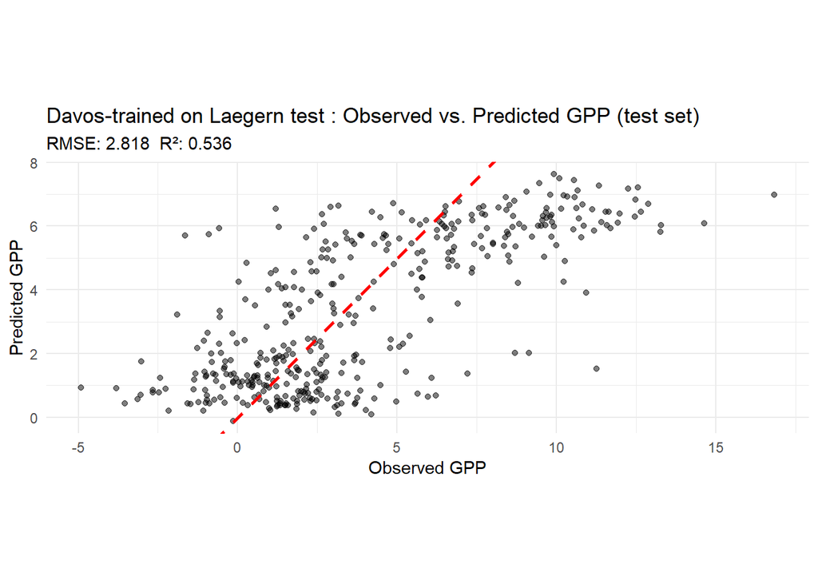

```r
davos_on_combined_metrics <- eval_model(
    model = model_davos_tuned,
    test_data = combined_test,
    model_name = "Davos-trained on combined test"
)
```

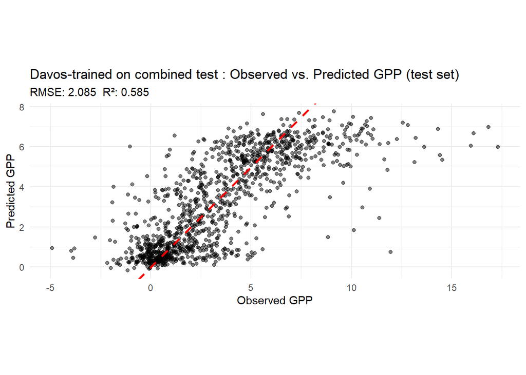

```r
# Create Table 1
table_model_davos_results <- dplyr::bind_rows(
  davos_on_davos_metrics,
  davos_on_laegeren_metrics,
  davos_on_combined_metrics
)
knitr::kable(table_model_davos_results,
             caption = "Performance of KNN model trained on Davos data only.",
             col.names = c("Evaluation scenario", "R²", "RMSE"))
```

Performance of KNN model trained on Davos data only.

| Evaluation scenario | R² | RMSE |
| --- | --- | --- |
| Davos-trained on Davos test | 0.745 | 1.411 |
| Davos-trained on Laegern test | 0.536 | 2.818 |
| Davos-trained on combined test | 0.585 | 2.085 |

```r
cat("Evaluating model trained on Laegern data\n")
```

```
## Evaluating model trained on Laegern data
```

```r
laegeren_on_laegeren_metrics <- eval_model(
  model = model_laegeren_tuned,
  test_data = laegeren_test,
  model_name = "Laegern-trained on Laegern test"
)
```

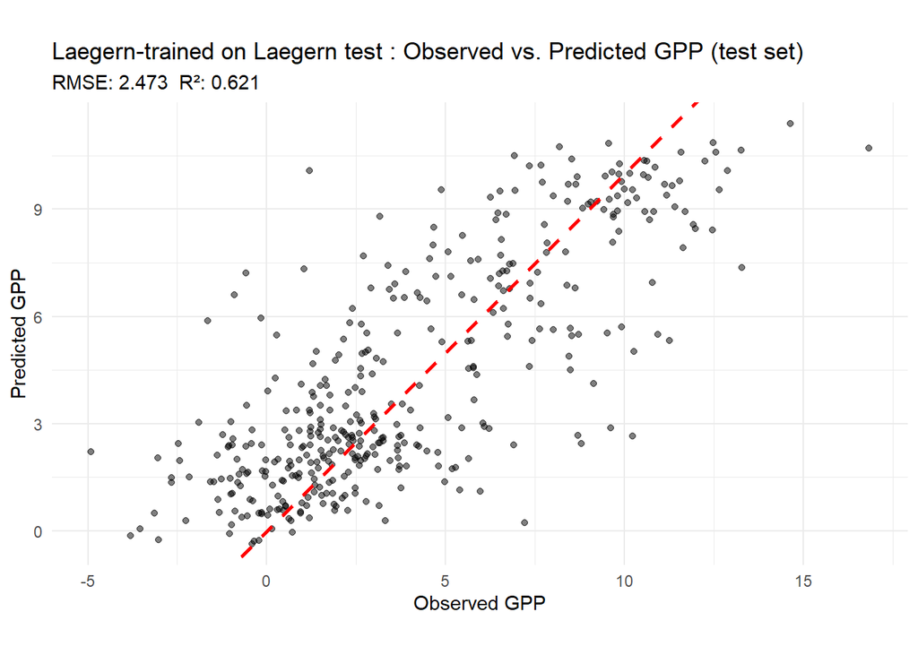

```r
laegeren_on_davos_metrics <- eval_model(
  model = model_laegeren_tuned,
  test_data = davos_test,
  model_name = "Laegern-trained on Davos test"
)
```

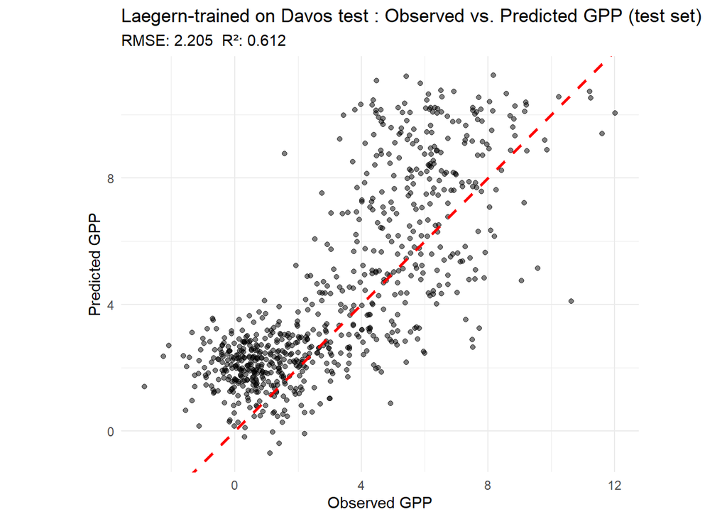

```r
laegeren_on_combined_metrics <- eval_model(
  model = model_laegeren_tuned,
  test_data = combined_test,
  model_name = "Laegern-trained on combined test"
)
```

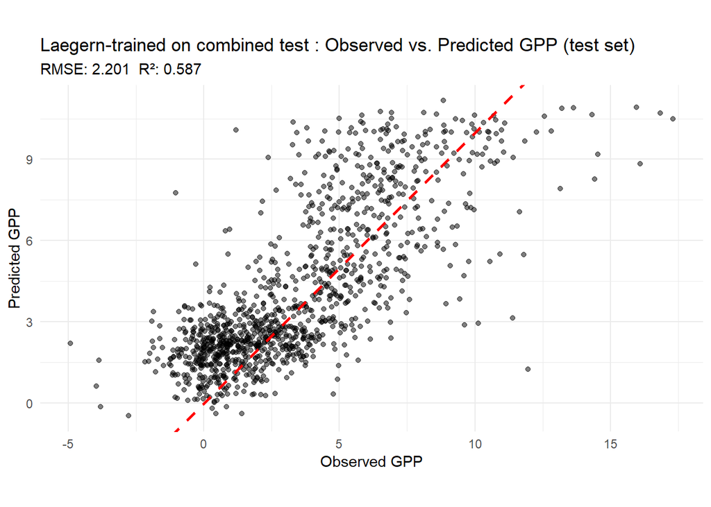

```r
# Create Table 2
table_model_laegeren_results <- dplyr::bind_rows(
  laegeren_on_laegeren_metrics,
  laegeren_on_davos_metrics,
  laegeren_on_combined_metrics
)
knitr::kable(table_model_laegeren_results,
             caption = "Performance of KNN model trained on Laegern data only.",
             col.names = c("Evaluation scenario", "R²", "RMSE"))
```

Performance of KNN model trained on Laegern data only.

| Evaluation scenario | R² | RMSE |
| --- | --- | --- |
| Laegern-trained on Laegern test | 0.621 | 2.473 |
| Laegern-trained on Davos test | 0.612 | 2.205 |
| Laegern-trained on combined test | 0.587 | 2.201 |

```r
cat("Evaluating model trained on combined data\n")
```

```
## Evaluating model trained on combined data
```

```r
combined_on_davos_metrics <- eval_model(
  model = model_combined_tuned,
  test_data = davos_test,
  model_name = "Combined-trained on Davos test"
)
```

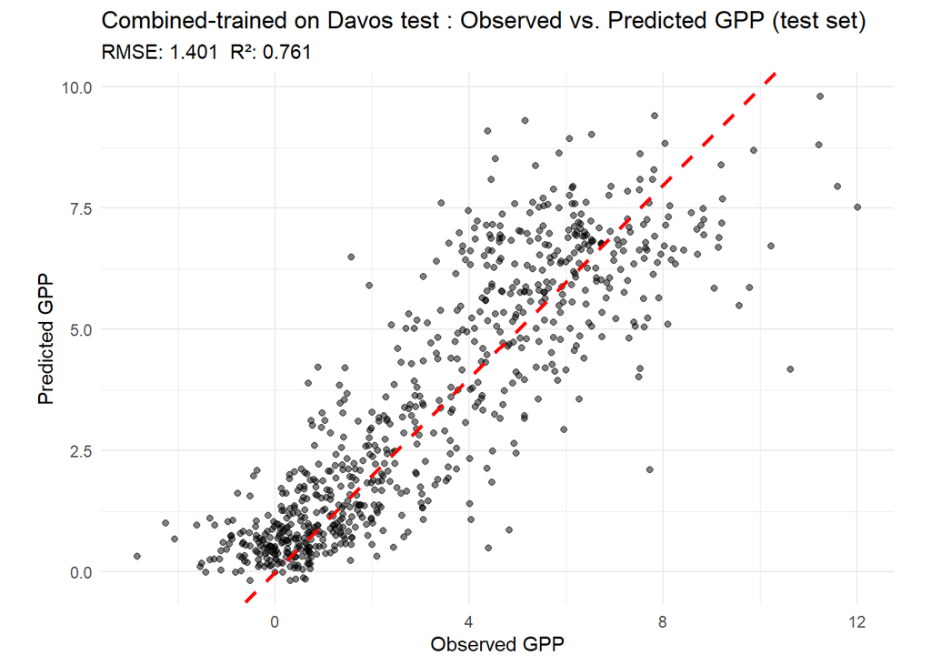

```r
combined_on_laegeren_metrics <- eval_model(
  model = model_combined_tuned,
  test_data = laegeren_test,
  model_name = "Combined-trained on Laegern test"
)
```

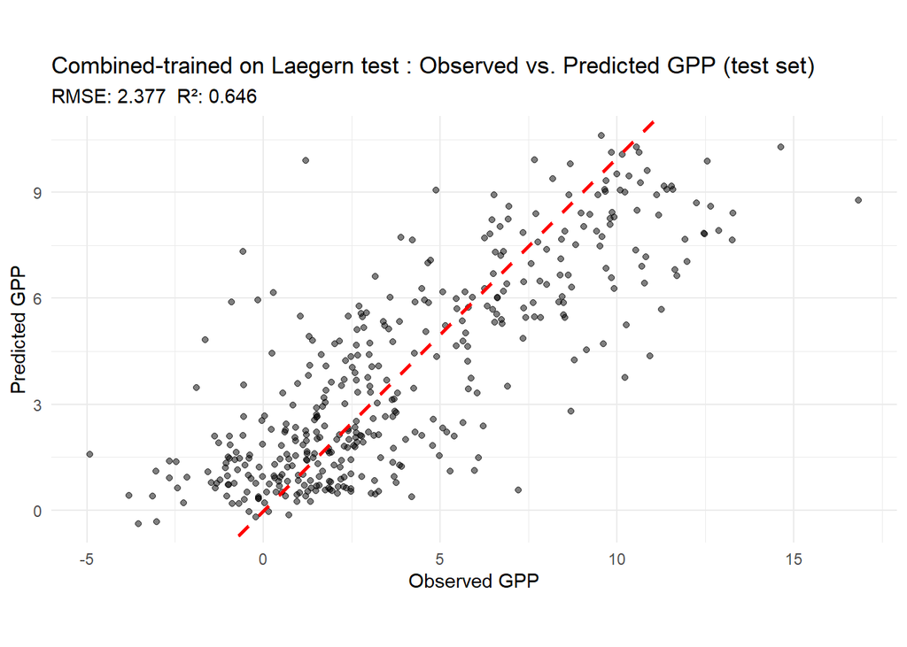

```r
combined_on_combined_metrics <- eval_model(
  model = model_combined_tuned,
  test_data = combined_test,
  model_name = "Combined-trained on combined test"
)
```

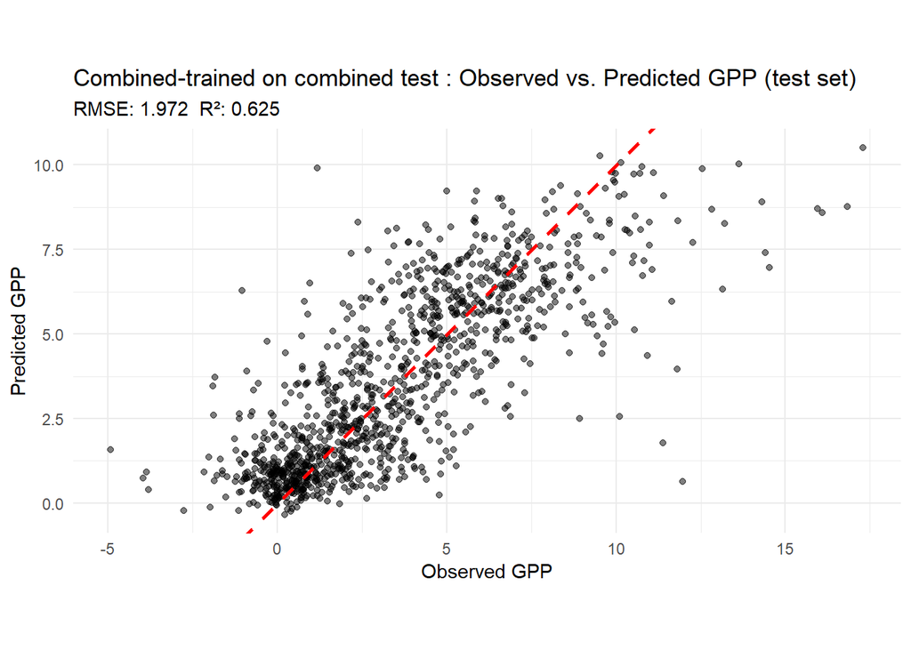

```r
# Create Table 3
table_model_combined_results <- dplyr::bind_rows(
  combined_on_davos_metrics,
  combined_on_laegeren_metrics,
  combined_on_combined_metrics
)
knitr::kable(table_model_combined_results,
             caption = "Performance of KNN model trained on combined (Davos & Laegern) data.",
             col.names = c("Evaluation scenario", "R²", "RMSE"))
```

Performance of KNN model trained on combined (Davos & Laegern) data.

| Evaluation scenario | R² | RMSE |
| --- | --- | --- |
| Combined-trained on Davos test | 0.761 | 1.401 |
| Combined-trained on Laegern test | 0.646 | 2.377 |
| Combined-trained on combined test | 0.625 | 1.972 |

## 4. Discussion

When evaluating the performance of models trained and tested on data from the same site, we can observe that the model trained on Davos data achieves a higher degree of accuracy for its own environment than the Laegern model does for its environment. The Davos model explains approximately 75% of the variance ($R^2$ = 0.745) on unseen Davos data , whereas the Laegern model explains about 62% of the variance ($R^2$ = 0.621) on its respective test set. This suggests that the GPP at the Davos site may be more consistently predicted by the chosen climatological variables.

However, when assessing the models performance on the unseen site, the Davos-trained model performs significantly worse when transferred. When applied to the Laegern test set, its explanatory power drops considerably ($R^2$ from 0.745 to 0.536) and its prediction error increases substantially (RMSE from 1.411 to 2.818). Curiously, the model trained on Laegern data does not show a similar degradation when predicting for Davos. Its $R^2$ remains almost the same (0.621 vs 0.612), and its RMSE actually improves when predicting for Davos compared to its own test set (2.205 vs 2.473). This could be due to the much greater environmental and vegetative variety at the Laegern site, which may lead to a model that has learned more robust and general patterns.

Finally, the results for the model trained on the combined dataset show an interesting behavior, as it outperforms both specialized models on their home test sets. For example, the combined models prediction for Davos data ($R^2$ = 0.761) is slightly more accurate than that of the specialized Davos model ($R^2$ = 0.745). Similarly, its prediction for Laegern data ($R^2$ = 0.646) is also better than that of the specialized Laegern model ($R^2$ = 0.621). This suggests that training on a more diverse dataset from both sites created a more robust and generalized model. For context, the specialized models performed moderately on the combined test set, with the Davos-trained model achieving an $R^2$ of 0.585 and the Laegern-trained model an $R^2$ of 0.587.

### 4.1. Time series analysis

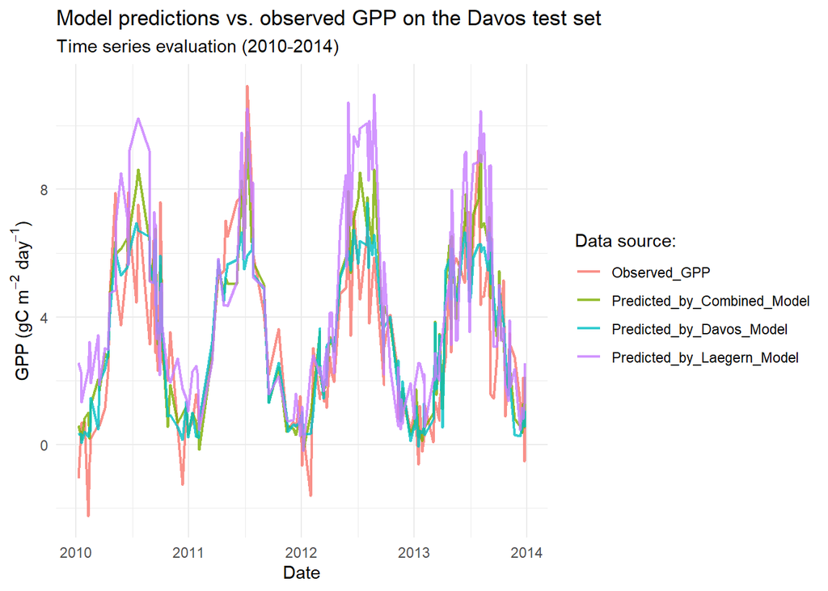

```r
# Time series visualization of the models for the Davos test set
# We create and reshape the data for the Davos test set
ts_davos_plot_data <- davos_test %>%
  select(TIMESTAMP, GPP) %>%
  mutate(
    Predicted_by_Davos_Model = predict(model_davos_tuned, newdata = davos_test),
    Predicted_by_Laegern_Model = predict(model_laegeren_tuned, newdata = davos_test),
    Predicted_by_Combined_Model = predict(model_combined_tuned, newdata = davos_test)
  ) %>%
  rename(Observed_GPP = GPP)

ts_davos_plot_long <- ts_davos_plot_data %>%
  pivot_longer(
    cols = c(Observed_GPP, Predicted_by_Davos_Model, Predicted_by_Laegern_Model, Predicted_by_Combined_Model),
    names_to = "Source",
    values_to = "GPP_Value"
  )

# We filter from 2010 to 2014 for a clearer visualization
ts_davos_plot_subset <- ts_davos_plot_long %>%
  filter(year(TIMESTAMP) >= 2010 & year(TIMESTAMP) < 2014)

# Create the plot using the filtered data
plot_davos_comparison_subset <- ggplot(ts_davos_plot_subset, aes(x = TIMESTAMP, y = GPP_Value, color = Source)) +
  geom_line(linewidth = 0.8, alpha = 0.8) +
  labs(
    title = "Model predictions vs. observed GPP on the Davos test set",
    subtitle = "Time series evaluation (2010-2014)",
    x = "Date",
    y = expression("GPP (gC m"^-2*" day"^-1*")"),
    color = "Data source:"
  ) +
  theme_minimal()

print(plot_davos_comparison_subset)
```

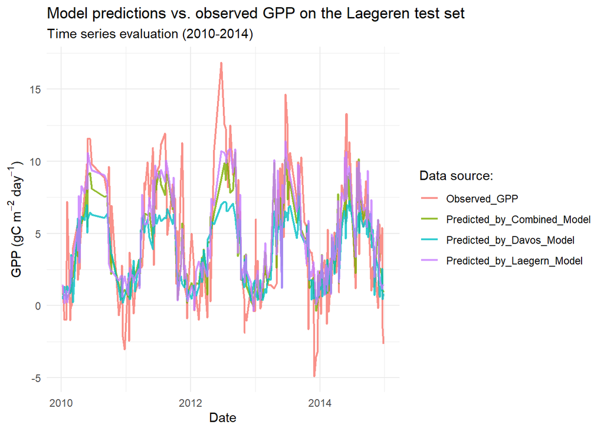

```r
# We do the same for the Laegern test set
ts_laegeren_plot_data <- laegeren_test %>%
  select(TIMESTAMP, GPP) %>%
  mutate(
    Predicted_by_Davos_Model = predict(model_davos_tuned, newdata = laegeren_test),
    Predicted_by_Laegern_Model = predict(model_laegeren_tuned, newdata = laegeren_test),
    Predicted_by_Combined_Model = predict(model_combined_tuned, newdata = laegeren_test)
  ) %>%
  rename(Observed_GPP = GPP)

ts_laegeren_plot_long <- ts_laegeren_plot_data %>%
  pivot_longer(
    cols = c(Observed_GPP, Predicted_by_Davos_Model, Predicted_by_Laegern_Model, Predicted_by_Combined_Model),
    names_to = "Source",
    values_to = "GPP_Value"
  )

ts_laegeren_plot_subset <- ts_laegeren_plot_long %>%
  filter(year(TIMESTAMP) >= 2010 & year(TIMESTAMP) < 2015)


plot_laegeren_comparison_subset <- ggplot(ts_laegeren_plot_subset, aes(x = TIMESTAMP, y = GPP_Value, color = Source)) +
  geom_line(linewidth = 0.8, alpha = 0.8) +
  labs(
    title = "Model predictions vs. observed GPP on the Laegeren test set",
    subtitle = "Time series evaluation (2010-2014)",
    x = "Date",
    y = expression("GPP (gC m"^-2*" day"^-1*")"),
    color = "Data source:"
  ) +
  theme_minimal()

print(plot_laegeren_comparison_subset)
```

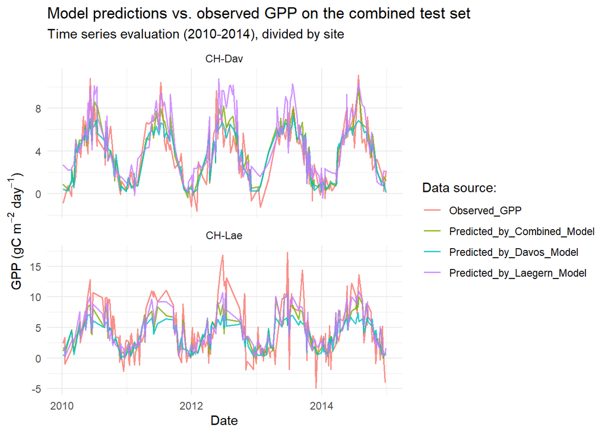

```r
# And for the combined test set
ts_combined_plot_data <- combined_test %>%
  select(TIMESTAMP, GPP, site_id) %>%
  mutate(
    Predicted_by_Davos_Model = predict(model_davos_tuned, newdata = combined_test),
    Predicted_by_Laegern_Model = predict(model_laegeren_tuned, newdata = combined_test),
    Predicted_by_Combined_Model = predict(model_combined_tuned, newdata = combined_test)
  ) %>%
  rename(Observed_GPP = GPP)

ts_combined_plot_long <- ts_combined_plot_data %>%
  pivot_longer(
    cols = c(Observed_GPP, Predicted_by_Davos_Model, Predicted_by_Laegern_Model, Predicted_by_Combined_Model),
    names_to = "Source",
    values_to = "GPP_Value"
  )

ts_combined_plot_subset <- ts_combined_plot_long %>%
  filter(year(TIMESTAMP) >= 2010 & year(TIMESTAMP) < 2015)

plot_combined_comparison_subset <- ggplot(ts_combined_plot_subset, aes(x = TIMESTAMP, y = GPP_Value, color = Source)) +
  geom_line(linewidth = 0.7, alpha = 0.8) +
  facet_wrap(~ site_id, scales = "free_y", ncol = 1) + # Separate panels for CH-Dav and CH-Lae data
  labs(
    title = "Model predictions vs. observed GPP on the combined test set",
    subtitle = "Time series evaluation (2010-2014), divided by site",
    x = "Date",
    y = expression("GPP (gC m"^-2*" day"^-1*")"),
    color = "Data source:"
  ) +
  theme_minimal()

print(plot_combined_comparison_subset)
```

### 4.2. Limitations of the combined model and true out-of-sample considerations

When we train and test the combined model using data from both sites, it is an out-of-sample test for those specific data points, but not truly out-of-sample for the types of environments it has learned. The model is tuned to the characteristics of Jura montains and subalpine forests.

If this model was tested against data from a completely different environment, such as a Mediterranean forest in Spain, we would expect its performance to be poor. A Spanish site would likely have a much warmer and drier climate and completely different vegetation types, representing predictor values and environmental conditions far outside the domain of the training data. This is an extrapolation problem, the prediction would exceed the range of the training data. This shows that even a good model is only reliable for the specific types of environments it has been trained on. We cannot guarantee it will perform well in a completely new place it has never seen before. To make a model that can accurately predict for new climate zones, we must include data from those zones in its training.

## 5. Sources

Etzold, S., Ruehr, N. K., Zweifel, R., Dobbertin, M., Zingg, A., Pluess, P., … & Buchmann, N. (2011). The carbon balance of two contrasting mountain forest ecosystems in Switzerland: similar annual trends, but seasonal differences. Ecosystems, 14, 1289-1309. DOI: 10.1007/s10021-011-9481-3.

Zielis, S., Etzold, S., Zweifel, R., Eugster, W., Haeni, M., & Buchmann, N. (2014). NEP of a Swiss subalpine forest is significantly driven not only by current but also by previous year’s weather. Biogeosciences, 11(6), 1627-1635. DOI: 10.5194/bg-11-1627-2014.